# Risk Factor Analysis

## Outcome Variable

**Outcome Variable:** stunted

## Predictor Variables

**Intervention Variable:** exclfeed3

**Adjustment Set:**

unadjusted

## Stratifying Variables

The analysis was stratified on these variable(s):

- agecat
- studyid
- country

## Data Summary

| agecat | studyid | country | exclfeed3 | stunted | n_cell | n |
| --- | --- | --- | --- | --- | --- | --- |
| Birth | ki0047075b-MAL-ED | BANGLADESH | 0 | 0 | 55 | 240 |
| Birth | ki0047075b-MAL-ED | BANGLADESH | 0 | 1 | 12 | 240 |
| Birth | ki0047075b-MAL-ED | BANGLADESH | 1 | 0 | 144 | 240 |
| Birth | ki0047075b-MAL-ED | BANGLADESH | 1 | 1 | 29 | 240 |
| Birth | ki0047075b-MAL-ED | BRAZIL | 0 | 0 | 103 | 185 |
| Birth | ki0047075b-MAL-ED | BRAZIL | 0 | 1 | 15 | 185 |
| Birth | ki0047075b-MAL-ED | BRAZIL | 1 | 0 | 63 | 185 |
| Birth | ki0047075b-MAL-ED | BRAZIL | 1 | 1 | 4 | 185 |
| Birth | ki0047075b-MAL-ED | INDIA | 0 | 0 | 62 | 196 |
| Birth | ki0047075b-MAL-ED | INDIA | 0 | 1 | 11 | 196 |
| Birth | ki0047075b-MAL-ED | INDIA | 1 | 0 | 103 | 196 |
| Birth | ki0047075b-MAL-ED | INDIA | 1 | 1 | 20 | 196 |
| Birth | ki0047075b-MAL-ED | NEPAL | 0 | 0 | 95 | 171 |
| Birth | ki0047075b-MAL-ED | NEPAL | 0 | 1 | 15 | 171 |
| Birth | ki0047075b-MAL-ED | NEPAL | 1 | 0 | 58 | 171 |
| Birth | ki0047075b-MAL-ED | NEPAL | 1 | 1 | 3 | 171 |
| Birth | ki0047075b-MAL-ED | PERU | 0 | 0 | 186 | 272 |
| Birth | ki0047075b-MAL-ED | PERU | 0 | 1 | 19 | 272 |
| Birth | ki0047075b-MAL-ED | PERU | 1 | 0 | 54 | 272 |
| Birth | ki0047075b-MAL-ED | PERU | 1 | 1 | 13 | 272 |
| Birth | ki0047075b-MAL-ED | SOUTH AFRICA | 0 | 0 | 180 | 233 |
| Birth | ki0047075b-MAL-ED | SOUTH AFRICA | 0 | 1 | 21 | 233 |
| Birth | ki0047075b-MAL-ED | SOUTH AFRICA | 1 | 0 | 29 | 233 |
| Birth | ki0047075b-MAL-ED | SOUTH AFRICA | 1 | 1 | 3 | 233 |
| Birth | ki0047075b-MAL-ED | TANZANIA, UNITED REPUBLIC OF | 0 | 0 | 66 | 119 |
| Birth | ki0047075b-MAL-ED | TANZANIA, UNITED REPUBLIC OF | 0 | 1 | 14 | 119 |
| Birth | ki0047075b-MAL-ED | TANZANIA, UNITED REPUBLIC OF | 1 | 0 | 35 | 119 |
| Birth | ki0047075b-MAL-ED | TANZANIA, UNITED REPUBLIC OF | 1 | 1 | 4 | 119 |
| Birth | ki1000108-CMC-V-BCS-2002 | INDIA | 0 | 0 | 0 | 4 |
| Birth | ki1000108-CMC-V-BCS-2002 | INDIA | 0 | 1 | 0 | 4 |

[output cut: 146 more lines]

The following strata were considered:

- agecat: 24 months, studyid: ki0047075b-MAL-ED, country: BANGLADESH
- agecat: 24 months, studyid: ki0047075b-MAL-ED, country: BRAZIL
- agecat: 24 months, studyid: ki0047075b-MAL-ED, country: INDIA
- agecat: 24 months, studyid: ki0047075b-MAL-ED, country: NEPAL
- agecat: 24 months, studyid: ki0047075b-MAL-ED, country: PERU
- agecat: 24 months, studyid: ki0047075b-MAL-ED, country: SOUTH AFRICA
- agecat: 24 months, studyid: ki0047075b-MAL-ED, country: TANZANIA, UNITED REPUBLIC OF
- agecat: 24 months, studyid: ki1000108-CMC-V-BCS-2002, country: INDIA
- agecat: 24 months, studyid: ki1000108-IRC, country: INDIA
- agecat: 24 months, studyid: ki1017093b-PROVIDE, country: BANGLADESH
- agecat: 24 months, studyid: ki1101329-Keneba, country: GAMBIA
- agecat: 24 months, studyid: ki1113344-GMS-Nepal, country: NEPAL
- agecat: 24 months, studyid: kiGH5241-JiVitA-3, country: BANGLADESH
- agecat: 24 months, studyid: kiGH5241-JiVitA-4, country: BANGLADESH
- agecat: 6 months, studyid: ki0047075b-MAL-ED, country: BANGLADESH
- agecat: 6 months, studyid: ki0047075b-MAL-ED, country: BRAZIL
- agecat: 6 months, studyid: ki0047075b-MAL-ED, country: INDIA
- agecat: 6 months, studyid: ki0047075b-MAL-ED, country: NEPAL
- agecat: 6 months, studyid: ki0047075b-MAL-ED, country: PERU
- agecat: 6 months, studyid: ki0047075b-MAL-ED, country: SOUTH AFRICA
- agecat: 6 months, studyid: ki0047075b-MAL-ED, country: TANZANIA, UNITED REPUBLIC OF
- agecat: 6 months, studyid: ki1000108-CMC-V-BCS-2002, country: INDIA
- agecat: 6 months, studyid: ki1000108-IRC, country: INDIA
- agecat: 6 months, studyid: ki1000109-EE, country: PAKISTAN
- agecat: 6 months, studyid: ki1000304b-SAS-CompFeed, country: INDIA
- agecat: 6 months, studyid: ki1017093b-PROVIDE, country: BANGLADESH
- agecat: 6 months, studyid: ki1101329-Keneba, country: GAMBIA
- agecat: 6 months, studyid: ki1113344-GMS-Nepal, country: NEPAL
- agecat: 6 months, studyid: kiGH5241-JiVitA-3, country: BANGLADESH
- agecat: 6 months, studyid: kiGH5241-JiVitA-4, country: BANGLADESH
- agecat: Birth, studyid: ki0047075b-MAL-ED, country: BANGLADESH
- agecat: Birth, studyid: ki0047075b-MAL-ED, country: BRAZIL
- agecat: Birth, studyid: ki0047075b-MAL-ED, country: INDIA
- agecat: Birth, studyid: ki0047075b-MAL-ED, country: NEPAL
- agecat: Birth, studyid: ki0047075b-MAL-ED, country: PERU
- agecat: Birth, studyid: ki0047075b-MAL-ED, country: SOUTH AFRICA
- agecat: Birth, studyid: ki0047075b-MAL-ED, country: TANZANIA, UNITED REPUBLIC OF
- agecat: Birth, studyid: ki1000108-CMC-V-BCS-2002, country: INDIA
- agecat: Birth, studyid: ki1000108-IRC, country: INDIA
- agecat: Birth, studyid: ki1000109-EE, country: PAKISTAN
- agecat: Birth, studyid: ki1000304b-SAS-CompFeed, country: INDIA
- agecat: Birth, studyid: ki1101329-Keneba, country: GAMBIA
- agecat: Birth, studyid: kiGH5241-JiVitA-3, country: BANGLADESH
- agecat: Birth, studyid: kiGH5241-JiVitA-4, country: BANGLADESH

### Dropped Strata

Some strata were dropped due to rare outcomes:

- agecat: Birth, studyid: ki0047075b-MAL-ED, country: BRAZIL
- agecat: Birth, studyid: ki0047075b-MAL-ED, country: NEPAL
- agecat: Birth, studyid: ki0047075b-MAL-ED, country: SOUTH AFRICA
- agecat: Birth, studyid: ki0047075b-MAL-ED, country: TANZANIA, UNITED REPUBLIC OF
- agecat: Birth, studyid: ki1000108-CMC-V-BCS-2002, country: INDIA
- agecat: Birth, studyid: ki1000108-IRC, country: INDIA
- agecat: Birth, studyid: ki1000109-EE, country: PAKISTAN
- agecat: Birth, studyid: ki1000304b-SAS-CompFeed, country: INDIA
- agecat: Birth, studyid: kiGH5241-JiVitA-4, country: BANGLADESH
- agecat: 6 months, studyid: ki0047075b-MAL-ED, country: BRAZIL
- agecat: 6 months, studyid: ki0047075b-MAL-ED, country: SOUTH AFRICA
- agecat: 6 months, studyid: ki1000108-CMC-V-BCS-2002, country: INDIA
- agecat: 6 months, studyid: ki1000108-IRC, country: INDIA
- agecat: 24 months, studyid: ki0047075b-MAL-ED, country: BRAZIL
- agecat: 24 months, studyid: ki1000108-CMC-V-BCS-2002, country: INDIA
- agecat: 24 months, studyid: ki1000108-IRC, country: INDIA

## Methods Detail

We’re interested in the causal parameters $E[Y_a]$ for all values of $a \in \mathcal{A}$. These parameters represent the mean outcome if, possibly contrary to fact, we intervened to set all units to have $A=a$. Under the randomization and positivity assumptions, these are identified by the statistical parameters $\psi_a=E_W[E_{Y|A,W}(Y|A=a,W)]$. In addition, we’re interested in the mean of $Y$, $E[Y]$ under no intervention (the observed mean). We will estimate these parameters by using SuperLearner to fit the relevant likelihood factors – $E_{Y|A,W}(Y|A=a,W)$ and $p(A=a|W)$, and then updating our likelihood fit using a joint TMLE.

For unadjusted analyses ($W=\{\}$), initial likelihoods were estimated using Lrnr_glm to estimate the simple $E(Y|A)$ and Lrnr_mean to estimate $p(A)$. For adjusted analyses, a small library containing Lrnr_glmnet, Lrnr_xgboost, and Lrnr_mean was used.

Having estimated these parameters, we will then use the delta method to estimate relative risks and attributable risks relative to a prespecified baseline level of $A$.

# Results Detail

## Results Plots

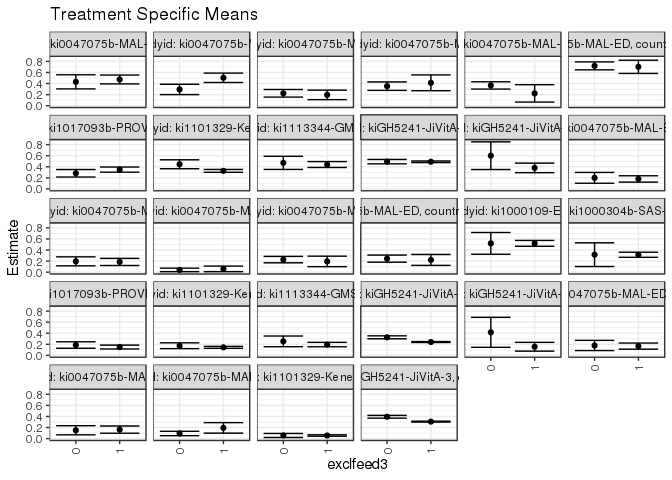

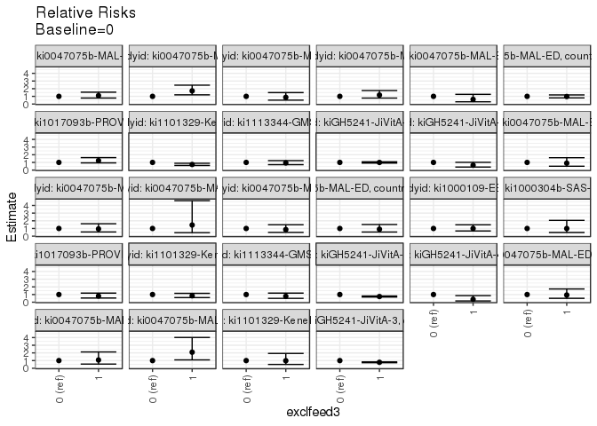

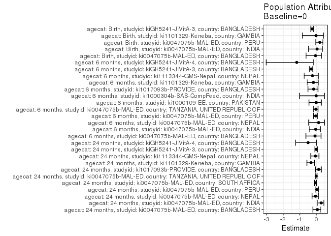

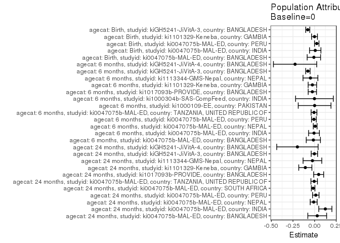

## Results Table

### Parameter: TSM

| agecat | studyid | country | intervention_level | baseline_level | estimate | ci_lower | ci_upper |
| --- | --- | --- | --- | --- | --- | --- | --- |
| Birth | ki0047075b-MAL-ED | BANGLADESH | 0 | NA | 0.1791045 | 0.0870988 | 0.2711101 |
| Birth | ki0047075b-MAL-ED | BANGLADESH | 1 | NA | 0.1676301 | 0.1118517 | 0.2234084 |
| Birth | ki0047075b-MAL-ED | INDIA | 0 | NA | 0.1506849 | 0.0684102 | 0.2329597 |
| Birth | ki0047075b-MAL-ED | INDIA | 1 | NA | 0.1626016 | 0.0972232 | 0.2279801 |
| Birth | ki0047075b-MAL-ED | PERU | 0 | NA | 0.0926829 | 0.0529134 | 0.1324524 |
| Birth | ki0047075b-MAL-ED | PERU | 1 | NA | 0.1940299 | 0.0991652 | 0.2888945 |
| Birth | ki1101329-Keneba | GAMBIA | 0 | NA | 0.0569620 | 0.0208096 | 0.0931144 |
| Birth | ki1101329-Keneba | GAMBIA | 1 | NA | 0.0560201 | 0.0429825 | 0.0690576 |
| Birth | kiGH5241-JiVitA-3 | BANGLADESH | 0 | NA | 0.3944857 | 0.3695203 | 0.4194511 |
| Birth | kiGH5241-JiVitA-3 | BANGLADESH | 1 | NA | 0.3067641 | 0.2988731 | 0.3146552 |
| 6 months | ki0047075b-MAL-ED | BANGLADESH | 0 | NA | 0.2000000 | 0.1025528 | 0.2974472 |
| 6 months | ki0047075b-MAL-ED | BANGLADESH | 1 | NA | 0.1802326 | 0.1226668 | 0.2377983 |
| 6 months | ki0047075b-MAL-ED | INDIA | 0 | NA | 0.1956522 | 0.1144154 | 0.2768889 |
| 6 months | ki0047075b-MAL-ED | INDIA | 1 | NA | 0.1843972 | 0.1202483 | 0.2485460 |
| 6 months | ki0047075b-MAL-ED | NEPAL | 0 | NA | 0.0405405 | 0.0086979 | 0.0723832 |
| 6 months | ki0047075b-MAL-ED | NEPAL | 1 | NA | 0.0588235 | 0.0086951 | 0.1089519 |
| 6 months | ki0047075b-MAL-ED | PERU | 0 | NA | 0.2266010 | 0.1689059 | 0.2842960 |
| 6 months | ki0047075b-MAL-ED | PERU | 1 | NA | 0.1940299 | 0.0991639 | 0.2888958 |
| 6 months | ki0047075b-MAL-ED | TANZANIA, UNITED REPUBLIC OF | 0 | NA | 0.2441860 | 0.1798494 | 0.3085227 |
| 6 months | ki0047075b-MAL-ED | TANZANIA, UNITED REPUBLIC OF | 1 | NA | 0.2205882 | 0.1218296 | 0.3193468 |
| 6 months | ki1000109-EE | PAKISTAN | 0 | NA | 0.5200000 | 0.3238960 | 0.7161040 |
| 6 months | ki1000109-EE | PAKISTAN | 1 | NA | 0.5202312 | 0.4675191 | 0.5729433 |
| 6 months | ki1000304b-SAS-CompFeed | INDIA | 0 | NA | 0.3157895 | 0.1014523 | 0.5301266 |
| 6 months | ki1000304b-SAS-CompFeed | INDIA | 1 | NA | 0.3139842 | 0.2679102 | 0.3600581 |
| 6 months | ki1017093b-PROVIDE | BANGLADESH | 0 | NA | 0.1871345 | 0.1286273 | 0.2456417 |
| 6 months | ki1017093b-PROVIDE | BANGLADESH | 1 | NA | 0.1504854 | 0.1159309 | 0.1850400 |
| 6 months | ki1101329-Keneba | GAMBIA | 0 | NA | 0.1741294 | 0.1216889 | 0.2265698 |
| 6 months | ki1101329-Keneba | GAMBIA | 1 | NA | 0.1453602 | 0.1277572 | 0.1629631 |
| 6 months | ki1113344-GMS-Nepal | NEPAL | 0 | NA | 0.2531646 | 0.1571752 | 0.3491539 |
| 6 months | ki1113344-GMS-Nepal | NEPAL | 1 | NA | 0.1952507 | 0.1552995 | 0.2352018 |
| 6 months | kiGH5241-JiVitA-3 | BANGLADESH | 0 | NA | 0.3263936 | 0.2994404 | 0.3533467 |
| 6 months | kiGH5241-JiVitA-3 | BANGLADESH | 1 | NA | 0.2411439 | 0.2326233 | 0.2496644 |
| 6 months | kiGH5241-JiVitA-4 | BANGLADESH | 0 | NA | 0.4166667 | 0.1460475 | 0.6872858 |
| 6 months | kiGH5241-JiVitA-4 | BANGLADESH | 1 | NA | 0.1558442 | 0.0767551 | 0.2349333 |
| 24 months | ki0047075b-MAL-ED | BANGLADESH | 0 | NA | 0.4310345 | 0.3032790 | 0.5587900 |
| 24 months | ki0047075b-MAL-ED | BANGLADESH | 1 | NA | 0.4733333 | 0.3932393 | 0.5534274 |
| 24 months | ki0047075b-MAL-ED | INDIA | 0 | NA | 0.2934783 | 0.2002233 | 0.3867333 |
| 24 months | ki0047075b-MAL-ED | INDIA | 1 | NA | 0.5037594 | 0.4185971 | 0.5889217 |
| 24 months | ki0047075b-MAL-ED | NEPAL | 0 | NA | 0.2237762 | 0.1553145 | 0.2922379 |
| 24 months | ki0047075b-MAL-ED | NEPAL | 1 | NA | 0.1951220 | 0.1091560 | 0.2810879 |
| 24 months | ki0047075b-MAL-ED | PERU | 0 | NA | 0.3529412 | 0.2770276 | 0.4288547 |
| 24 months | ki0047075b-MAL-ED | PERU | 1 | NA | 0.4130435 | 0.2703960 | 0.5556909 |
| 24 months | ki0047075b-MAL-ED | SOUTH AFRICA | 0 | NA | 0.3658537 | 0.2997755 | 0.4319318 |
| 24 months | ki0047075b-MAL-ED | SOUTH AFRICA | 1 | NA | 0.2222222 | 0.0650681 | 0.3793763 |
| 24 months | ki0047075b-MAL-ED | TANZANIA, UNITED REPUBLIC OF | 0 | NA | 0.7189542 | 0.6475576 | 0.7903509 |
| 24 months | ki0047075b-MAL-ED | TANZANIA, UNITED REPUBLIC OF | 1 | NA | 0.7017544 | 0.5827051 | 0.8208037 |
| 24 months | ki1017093b-PROVIDE | BANGLADESH | 0 | NA | 0.2823529 | 0.2146275 | 0.3500784 |
| 24 months | ki1017093b-PROVIDE | BANGLADESH | 1 | NA | 0.3488943 | 0.3025496 | 0.3952391 |
| 24 months | ki1101329-Keneba | GAMBIA | 0 | NA | 0.4452055 | 0.3645617 | 0.5258493 |
| 24 months | ki1101329-Keneba | GAMBIA | 1 | NA | 0.3257457 | 0.3000022 | 0.3514892 |
| 24 months | ki1113344-GMS-Nepal | NEPAL | 0 | NA | 0.4705882 | 0.3518066 | 0.5893698 |
| 24 months | ki1113344-GMS-Nepal | NEPAL | 1 | NA | 0.4404762 | 0.3873282 | 0.4936242 |
| 24 months | kiGH5241-JiVitA-3 | BANGLADESH | 0 | NA | 0.4927184 | 0.4534120 | 0.5320249 |
| 24 months | kiGH5241-JiVitA-3 | BANGLADESH | 1 | NA | 0.4902222 | 0.4761802 | 0.5042641 |
| 24 months | kiGH5241-JiVitA-4 | BANGLADESH | 0 | NA | 0.6000000 | 0.3502268 | 0.8497732 |
| 24 months | kiGH5241-JiVitA-4 | BANGLADESH | 1 | NA | 0.3795620 | 0.2934360 | 0.4656880 |

### Parameter: E(Y)

| agecat | studyid | country | intervention_level | baseline_level | estimate | ci_lower | ci_upper |
| --- | --- | --- | --- | --- | --- | --- | --- |
| Birth | ki0047075b-MAL-ED | BANGLADESH | NA | NA | 0.1708333 | 0.1231182 | 0.2185485 |
| Birth | ki0047075b-MAL-ED | INDIA | NA | NA | 0.1581633 | 0.1069482 | 0.2093783 |
| Birth | ki0047075b-MAL-ED | PERU | NA | NA | 0.1176471 | 0.0792874 | 0.1560068 |
| Birth | ki1101329-Keneba | GAMBIA | NA | NA | 0.0561300 | 0.0438654 | 0.0683946 |
| Birth | kiGH5241-JiVitA-3 | BANGLADESH | NA | NA | 0.3156066 | 0.3080361 | 0.3231771 |
| 6 months | ki0047075b-MAL-ED | BANGLADESH | NA | NA | 0.1856540 | 0.1360463 | 0.2352617 |
| 6 months | ki0047075b-MAL-ED | INDIA | NA | NA | 0.1888412 | 0.1384789 | 0.2392035 |
| 6 months | ki0047075b-MAL-ED | NEPAL | NA | NA | 0.0472103 | 0.0199192 | 0.0745014 |
| 6 months | ki0047075b-MAL-ED | PERU | NA | NA | 0.2185185 | 0.1691358 | 0.2679013 |
| 6 months | ki0047075b-MAL-ED | TANZANIA, UNITED REPUBLIC OF | NA | NA | 0.2375000 | 0.1835488 | 0.2914512 |
| 6 months | ki1000109-EE | PAKISTAN | NA | NA | 0.5202156 | 0.4693105 | 0.5711208 |
| 6 months | ki1000304b-SAS-CompFeed | INDIA | NA | NA | 0.3140704 | 0.2712850 | 0.3568557 |
| 6 months | ki1017093b-PROVIDE | BANGLADESH | NA | NA | 0.1612350 | 0.1313580 | 0.1911120 |
| 6 months | ki1101329-Keneba | GAMBIA | NA | NA | 0.1486797 | 0.1319680 | 0.1653914 |
| 6 months | ki1113344-GMS-Nepal | NEPAL | NA | NA | 0.2052402 | 0.1682114 | 0.2422689 |
| 6 months | kiGH5241-JiVitA-3 | BANGLADESH | NA | NA | 0.2489405 | 0.2407278 | 0.2571531 |
| 6 months | kiGH5241-JiVitA-4 | BANGLADESH | NA | NA | 0.1910112 | 0.1139351 | 0.2680874 |
| 24 months | ki0047075b-MAL-ED | BANGLADESH | NA | NA | 0.4615385 | 0.3936268 | 0.5294501 |
| 24 months | ki0047075b-MAL-ED | INDIA | NA | NA | 0.4177778 | 0.3531914 | 0.4823642 |
| 24 months | ki0047075b-MAL-ED | NEPAL | NA | NA | 0.2133333 | 0.1596859 | 0.2669808 |
| 24 months | ki0047075b-MAL-ED | PERU | NA | NA | 0.3668342 | 0.2997053 | 0.4339630 |
| 24 months | ki0047075b-MAL-ED | SOUTH AFRICA | NA | NA | 0.3491379 | 0.2876648 | 0.4106110 |
| 24 months | ki0047075b-MAL-ED | TANZANIA, UNITED REPUBLIC OF | NA | NA | 0.7142857 | 0.6530398 | 0.7755316 |
| 24 months | ki1017093b-PROVIDE | BANGLADESH | NA | NA | 0.3292894 | 0.2909105 | 0.3676684 |
| 24 months | ki1101329-Keneba | GAMBIA | NA | NA | 0.3380282 | 0.3134158 | 0.3626405 |
| 24 months | ki1113344-GMS-Nepal | NEPAL | NA | NA | 0.4455446 | 0.3970186 | 0.4940706 |
| 24 months | kiGH5241-JiVitA-3 | BANGLADESH | NA | NA | 0.4904688 | 0.4770397 | 0.5038978 |
| 24 months | kiGH5241-JiVitA-4 | BANGLADESH | NA | NA | 0.4013158 | 0.3195309 | 0.4831007 |

### Parameter: RR

| agecat | studyid | country | intervention_level | baseline_level | estimate | ci_lower | ci_upper |
| --- | --- | --- | --- | --- | --- | --- | --- |
| Birth | ki0047075b-MAL-ED | BANGLADESH | 0 | 0 | 1.0000000 | 1.0000000 | 1.0000000 |
| Birth | ki0047075b-MAL-ED | BANGLADESH | 1 | 0 | 0.9359345 | 0.5074989 | 1.7260596 |
| Birth | ki0047075b-MAL-ED | INDIA | 0 | 0 | 1.0000000 | 1.0000000 | 1.0000000 |
| Birth | ki0047075b-MAL-ED | INDIA | 1 | 0 | 1.0790835 | 0.5477344 | 2.1258865 |
| Birth | ki0047075b-MAL-ED | PERU | 0 | 0 | 1.0000000 | 1.0000000 | 1.0000000 |
| Birth | ki0047075b-MAL-ED | PERU | 1 | 0 | 2.0934800 | 1.0923374 | 4.0121838 |
| Birth | ki1101329-Keneba | GAMBIA | 0 | 0 | 1.0000000 | 1.0000000 | 1.0000000 |
| Birth | ki1101329-Keneba | GAMBIA | 1 | 0 | 0.9834634 | 0.5002360 | 1.9334878 |
| Birth | kiGH5241-JiVitA-3 | BANGLADESH | 0 | 0 | 1.0000000 | 1.0000000 | 1.0000000 |
| Birth | kiGH5241-JiVitA-3 | BANGLADESH | 1 | 0 | 0.7776306 | 0.7264792 | 0.8323837 |
| 6 months | ki0047075b-MAL-ED | BANGLADESH | 0 | 0 | 1.0000000 | 1.0000000 | 1.0000000 |
| 6 months | ki0047075b-MAL-ED | BANGLADESH | 1 | 0 | 0.9011628 | 0.5032534 | 1.6136888 |
| 6 months | ki0047075b-MAL-ED | INDIA | 0 | 0 | 1.0000000 | 1.0000000 | 1.0000000 |
| 6 months | ki0047075b-MAL-ED | INDIA | 1 | 0 | 0.9424744 | 0.5483006 | 1.6200201 |
| 6 months | ki0047075b-MAL-ED | NEPAL | 0 | 0 | 1.0000000 | 1.0000000 | 1.0000000 |
| 6 months | ki0047075b-MAL-ED | NEPAL | 1 | 0 | 1.4509804 | 0.4553431 | 4.6236432 |
| 6 months | ki0047075b-MAL-ED | PERU | 0 | 0 | 1.0000000 | 1.0000000 | 1.0000000 |
| 6 months | ki0047075b-MAL-ED | PERU | 1 | 0 | 0.8562622 | 0.4934045 | 1.4859713 |
| 6 months | ki0047075b-MAL-ED | TANZANIA, UNITED REPUBLIC OF | 0 | 0 | 1.0000000 | 1.0000000 | 1.0000000 |
| 6 months | ki0047075b-MAL-ED | TANZANIA, UNITED REPUBLIC OF | 1 | 0 | 0.9033613 | 0.5373465 | 1.5186880 |
| 6 months | ki1000109-EE | PAKISTAN | 0 | 0 | 1.0000000 | 1.0000000 | 1.0000000 |
| 6 months | ki1000109-EE | PAKISTAN | 1 | 0 | 1.0004446 | 0.6770209 | 1.4783731 |
| 6 months | ki1000304b-SAS-CompFeed | INDIA | 0 | 0 | 1.0000000 | 1.0000000 | 1.0000000 |
| 6 months | ki1000304b-SAS-CompFeed | INDIA | 1 | 0 | 0.9942832 | 0.4810773 | 2.0549693 |
| 6 months | ki1017093b-PROVIDE | BANGLADESH | 0 | 0 | 1.0000000 | 1.0000000 | 1.0000000 |
| 6 months | ki1017093b-PROVIDE | BANGLADESH | 1 | 0 | 0.8041566 | 0.5455989 | 1.1852439 |
| 6 months | ki1101329-Keneba | GAMBIA | 0 | 0 | 1.0000000 | 1.0000000 | 1.0000000 |
| 6 months | ki1101329-Keneba | GAMBIA | 1 | 0 | 0.8347826 | 0.6033982 | 1.1548957 |
| 6 months | ki1113344-GMS-Nepal | NEPAL | 0 | 0 | 1.0000000 | 1.0000000 | 1.0000000 |
| 6 months | ki1113344-GMS-Nepal | NEPAL | 1 | 0 | 0.7712401 | 0.5012746 | 1.1865977 |
| 6 months | kiGH5241-JiVitA-3 | BANGLADESH | 0 | 0 | 1.0000000 | 1.0000000 | 1.0000000 |
| 6 months | kiGH5241-JiVitA-3 | BANGLADESH | 1 | 0 | 0.7388132 | 0.6761161 | 0.8073243 |
| 6 months | kiGH5241-JiVitA-4 | BANGLADESH | 0 | 0 | 1.0000000 | 1.0000000 | 1.0000000 |
| 6 months | kiGH5241-JiVitA-4 | BANGLADESH | 1 | 0 | 0.3740260 | 0.1633044 | 0.8566541 |
| 24 months | ki0047075b-MAL-ED | BANGLADESH | 0 | 0 | 1.0000000 | 1.0000000 | 1.0000000 |
| 24 months | ki0047075b-MAL-ED | BANGLADESH | 1 | 0 | 1.0981333 | 0.7806079 | 1.5448176 |
| 24 months | ki0047075b-MAL-ED | INDIA | 0 | 0 | 1.0000000 | 1.0000000 | 1.0000000 |
| 24 months | ki0047075b-MAL-ED | INDIA | 1 | 0 | 1.7165135 | 1.1976555 | 2.4601553 |
| 24 months | ki0047075b-MAL-ED | NEPAL | 0 | 0 | 1.0000000 | 1.0000000 | 1.0000000 |
| 24 months | ki0047075b-MAL-ED | NEPAL | 1 | 0 | 0.8719512 | 0.5099701 | 1.4908697 |
| 24 months | ki0047075b-MAL-ED | PERU | 0 | 0 | 1.0000000 | 1.0000000 | 1.0000000 |
| 24 months | ki0047075b-MAL-ED | PERU | 1 | 0 | 1.1702899 | 0.7791063 | 1.7578838 |
| 24 months | ki0047075b-MAL-ED | SOUTH AFRICA | 0 | 0 | 1.0000000 | 1.0000000 | 1.0000000 |
| 24 months | ki0047075b-MAL-ED | SOUTH AFRICA | 1 | 0 | 0.6074074 | 0.2927464 | 1.2602845 |
| 24 months | ki0047075b-MAL-ED | TANZANIA, UNITED REPUBLIC OF | 0 | 0 | 1.0000000 | 1.0000000 | 1.0000000 |
| 24 months | ki0047075b-MAL-ED | TANZANIA, UNITED REPUBLIC OF | 1 | 0 | 0.9760766 | 0.8018867 | 1.1881049 |
| 24 months | ki1017093b-PROVIDE | BANGLADESH | 0 | 0 | 1.0000000 | 1.0000000 | 1.0000000 |
| 24 months | ki1017093b-PROVIDE | BANGLADESH | 1 | 0 | 1.2356675 | 0.9393430 | 1.6254703 |
| 24 months | ki1101329-Keneba | GAMBIA | 0 | 0 | 1.0000000 | 1.0000000 | 1.0000000 |
| 24 months | ki1101329-Keneba | GAMBIA | 1 | 0 | 0.7316749 | 0.6004675 | 0.8915523 |
| 24 months | ki1113344-GMS-Nepal | NEPAL | 0 | 0 | 1.0000000 | 1.0000000 | 1.0000000 |
| 24 months | ki1113344-GMS-Nepal | NEPAL | 1 | 0 | 0.9360119 | 0.7075867 | 1.2381781 |
| 24 months | kiGH5241-JiVitA-3 | BANGLADESH | 0 | 0 | 1.0000000 | 1.0000000 | 1.0000000 |
| 24 months | kiGH5241-JiVitA-3 | BANGLADESH | 1 | 0 | 0.9949337 | 0.9153836 | 1.0813969 |
| 24 months | kiGH5241-JiVitA-4 | BANGLADESH | 0 | 0 | 1.0000000 | 1.0000000 | 1.0000000 |
| 24 months | kiGH5241-JiVitA-4 | BANGLADESH | 1 | 0 | 0.6326034 | 0.3951593 | 1.0127235 |

### Parameter: PAR

| agecat | studyid | country | intervention_level | baseline_level | estimate | ci_lower | ci_upper |
| --- | --- | --- | --- | --- | --- | --- | --- |
| Birth | ki0047075b-MAL-ED | BANGLADESH | 0 | NA | -0.0082711 | -0.0858306 | 0.0692883 |
| Birth | ki0047075b-MAL-ED | INDIA | 0 | NA | 0.0074783 | -0.0584747 | 0.0734314 |
| Birth | ki0047075b-MAL-ED | PERU | 0 | NA | 0.0249641 | -0.0009015 | 0.0508297 |
| Birth | ki1101329-Keneba | GAMBIA | 0 | NA | -0.0008320 | -0.0347789 | 0.0331148 |
| Birth | kiGH5241-JiVitA-3 | BANGLADESH | 0 | NA | -0.0788791 | -0.1024040 | -0.0553541 |
| 6 months | ki0047075b-MAL-ED | BANGLADESH | 0 | NA | -0.0143460 | -0.0964930 | 0.0678010 |
| 6 months | ki0047075b-MAL-ED | INDIA | 0 | NA | -0.0068110 | -0.0694545 | 0.0558326 |
| 6 months | ki0047075b-MAL-ED | NEPAL | 0 | NA | 0.0066698 | -0.0150246 | 0.0283641 |
| 6 months | ki0047075b-MAL-ED | PERU | 0 | NA | -0.0080825 | -0.0356863 | 0.0195213 |
| 6 months | ki0047075b-MAL-ED | TANZANIA, UNITED REPUBLIC OF | 0 | NA | -0.0066860 | -0.0401087 | 0.0267366 |
| 6 months | ki1000109-EE | PAKISTAN | 0 | NA | 0.0002156 | -0.1891656 | 0.1895969 |
| 6 months | ki1000304b-SAS-CompFeed | INDIA | 0 | NA | -0.0017191 | -0.2199177 | 0.2164795 |
| 6 months | ki1017093b-PROVIDE | BANGLADESH | 0 | NA | -0.0258995 | -0.0739377 | 0.0221387 |
| 6 months | ki1101329-Keneba | GAMBIA | 0 | NA | -0.0254497 | -0.0743850 | 0.0234857 |
| 6 months | ki1113344-GMS-Nepal | NEPAL | 0 | NA | -0.0479244 | -0.1339852 | 0.0381365 |
| 6 months | kiGH5241-JiVitA-3 | BANGLADESH | 0 | NA | -0.0774531 | -0.1028963 | -0.0520098 |
| 6 months | kiGH5241-JiVitA-4 | BANGLADESH | 0 | NA | -0.2256554 | -0.4758250 | 0.0245141 |
| 24 months | ki0047075b-MAL-ED | BANGLADESH | 0 | NA | 0.0305040 | -0.0782669 | 0.1392748 |
| 24 months | ki0047075b-MAL-ED | INDIA | 0 | NA | 0.1242995 | 0.0484306 | 0.2001685 |
| 24 months | ki0047075b-MAL-ED | NEPAL | 0 | NA | -0.0104429 | -0.0505346 | 0.0296488 |
| 24 months | ki0047075b-MAL-ED | PERU | 0 | NA | 0.0138930 | -0.0236257 | 0.0514117 |
| 24 months | ki0047075b-MAL-ED | SOUTH AFRICA | 0 | NA | -0.0167157 | -0.0374262 | 0.0039947 |
| 24 months | ki0047075b-MAL-ED | TANZANIA, UNITED REPUBLIC OF | 0 | NA | -0.0046685 | -0.0423618 | 0.0330247 |
| 24 months | ki1017093b-PROVIDE | BANGLADESH | 0 | NA | 0.0469365 | -0.0110025 | 0.1048755 |
| 24 months | ki1101329-Keneba | GAMBIA | 0 | NA | -0.1071773 | -0.1831501 | -0.0312045 |
| 24 months | ki1113344-GMS-Nepal | NEPAL | 0 | NA | -0.0250437 | -0.1332761 | 0.0831887 |
| 24 months | kiGH5241-JiVitA-3 | BANGLADESH | 0 | NA | -0.0022497 | -0.0392356 | 0.0347362 |
| 24 months | kiGH5241-JiVitA-4 | BANGLADESH | 0 | NA | -0.1986842 | -0.4379272 | 0.0405588 |

### Parameter: PAF

| agecat | studyid | country | intervention_level | baseline_level | estimate | ci_lower | ci_upper |
| --- | --- | --- | --- | --- | --- | --- | --- |
| Birth | ki0047075b-MAL-ED | BANGLADESH | 0 | NA | -0.0484165 | -0.6164168 | 0.3199915 |
| Birth | ki0047075b-MAL-ED | INDIA | 0 | NA | 0.0472824 | -0.4755962 | 0.3848785 |
| Birth | ki0047075b-MAL-ED | PERU | 0 | NA | 0.2121951 | -0.0298709 | 0.3973647 |
| Birth | ki1101329-Keneba | GAMBIA | 0 | NA | -0.0148235 | -0.8416510 | 0.4407916 |
| Birth | kiGH5241-JiVitA-3 | BANGLADESH | 0 | NA | -0.2499284 | -0.3267664 | -0.1775403 |
| 6 months | ki0047075b-MAL-ED | BANGLADESH | 0 | NA | -0.0772727 | -0.6240775 | 0.2854303 |
| 6 months | ki0047075b-MAL-ED | INDIA | 0 | NA | -0.0360672 | -0.4269519 | 0.2477425 |
| 6 months | ki0047075b-MAL-ED | NEPAL | 0 | NA | 0.1412776 | -0.4550333 | 0.4932047 |
| 6 months | ki0047075b-MAL-ED | PERU | 0 | NA | -0.0369876 | -0.1711951 | 0.0818411 |
| 6 months | ki0047075b-MAL-ED | TANZANIA, UNITED REPUBLIC OF | 0 | NA | -0.0281518 | -0.1789046 | 0.1033235 |
| 6 months | ki1000109-EE | PAKISTAN | 0 | NA | 0.0004145 | -0.4387579 | 0.3055321 |
| 6 months | ki1000304b-SAS-CompFeed | INDIA | 0 | NA | -0.0054737 | -1.0068383 | 0.4962338 |
| 6 months | ki1017093b-PROVIDE | BANGLADESH | 0 | NA | -0.1606321 | -0.4992400 | 0.1015002 |
| 6 months | ki1101329-Keneba | GAMBIA | 0 | NA | -0.1711712 | -0.5507663 | 0.1155070 |
| 6 months | ki1113344-GMS-Nepal | NEPAL | 0 | NA | -0.2335039 | -0.7318254 | 0.1214288 |
| 6 months | kiGH5241-JiVitA-3 | BANGLADESH | 0 | NA | -0.3111309 | -0.4176736 | -0.2125952 |
| 6 months | kiGH5241-JiVitA-4 | BANGLADESH | 0 | NA | -1.1813726 | -3.0281473 | -0.1812841 |
| 24 months | ki0047075b-MAL-ED | BANGLADESH | 0 | NA | 0.0660920 | -0.2021363 | 0.2744714 |
| 24 months | ki0047075b-MAL-ED | INDIA | 0 | NA | 0.2975254 | 0.0902289 | 0.4575883 |
| 24 months | ki0047075b-MAL-ED | NEPAL | 0 | NA | -0.0489510 | -0.2545598 | 0.1229607 |
| 24 months | ki0047075b-MAL-ED | PERU | 0 | NA | 0.0378727 | -0.0700683 | 0.1349254 |
| 24 months | ki0047075b-MAL-ED | SOUTH AFRICA | 0 | NA | -0.0478771 | -0.1089858 | 0.0098642 |
| 24 months | ki0047075b-MAL-ED | TANZANIA, UNITED REPUBLIC OF | 0 | NA | -0.0065359 | -0.0607269 | 0.0448865 |
| 24 months | ki1017093b-PROVIDE | BANGLADESH | 0 | NA | 0.1425387 | -0.0526141 | 0.3015105 |
| 24 months | ki1101329-Keneba | GAMBIA | 0 | NA | -0.3170662 | -0.5626196 | -0.1100996 |
| 24 months | ki1113344-GMS-Nepal | NEPAL | 0 | NA | -0.0562091 | -0.3294044 | 0.1608439 |
| 24 months | kiGH5241-JiVitA-3 | BANGLADESH | 0 | NA | -0.0045868 | -0.0828991 | 0.0680622 |
| 24 months | kiGH5241-JiVitA-4 | BANGLADESH | 0 | NA | -0.4950820 | -1.2461071 | 0.0048248 |